# PStat 231 Final Project: Stress Response from Environmental Factors

Gabrielle Salo

2022-12-06

## Introduction

Environmental factors affect animal responses at both the physical and chemical level. One chemical level is the stress hormone. 14 biologists collected information on various animals and recorded the information in a single public database called HormoneBase. HormoneBase is a database that aims to include all available measures of plasma androgens (testosterone and 11-ketotestosterone) and glucocorticoids (corticosterone and cortisol; including baseline and stress-induced measures) from free-living, adult vertebrates, including fish, amphibians, reptiles, birds, and mammals. $^1$ This paper aims to analyze this information through machine learning techniques to identify if stress levels can be predicted or determined accurately based on external factors. Specifically, the interest is on the Female population.

### Research Goal

This paper aims to predict the categorical response of female hormone stress levels, specifically the base corticosterone/corisol concentrations, based on the predictors available from the combined databases. The potentially available variables for utilization captured in the multiple data sources include: Stressor type, location, elevation, and taxonomic group, among others.

If conclusive on a high absolute correlation between stress levels and other factors in animals, this could indicate an interest in said confounding locational or environmental factors that may affect human stress hormone concentration levels for future studies.

### Project Outline

The goal is to look at the female base corticosterone/ cortisol levels in animals across the world to identify if environmental factors affect the base stress hormone level. The data under analysis comes from the HormoneBase database, which contains compiled measures of steroid hormone levels from free-living populations of vertebrates. The information was gathered by multiple groups and aggregated to facilitate large-scale comparative analysis.

Studies were selected for inclusion if they contained data on circulating glucocorticoids (baseline and or stress-induced corticosterone/cortisol) or androgens (testosterone/11-ketotestosterone) that: (i) were from free-living populations, (ii) were collected from adults that had not been subject to an experimental manipulation prior to sampling (e.g., of hormones or the environment), (iii) measured plasma levels, (iv) did not pool data across males and females, or across adults and juveniles, and (v) were reported in or could be converted to a standard unit of measurement (ng/mL). Published values were obtained from text, tables, or supplementary materials, or extracted from published figures using the program Data Thief III. When papers did not directly report the coefficient of variation, it was calculated from the standard deviation or standard error and sample size.

This paper will cover the following forms of analysis to reach a determination for the research goal.

- Exploratory Data Analysis
- Model Building: Data Splitting, Recipe Building, and K-Fold Cross Validation
- Model Option Evaluation: Autoplot Evaluations and Accuracy of Classification, Random Forest, Boosted, and K-Nearest Neighbor models
- Best Fit Model: Evaluations and Results
- Conclusion

This paper aims to identify a model through machine learning of the data recorded in HormoneBase.

## Exploratory Data Analysis

This preliminary step is a requirement before any analysis can be completed for any statistical modeling or machine learning. Here, the data is loaded, viewed, cleaned, and explored for a clear understanding of trends on relevant variables as well as determining variables or rows to keep. For instance, if the response variable has blank/unrecorded responses, those records would not be helpful in the final model. Likewise, if a predictor is primarily unrecorded, or has miscellaneous or ungroupable factor values, it may be an indication to remove the variable. The determinations of what to keep and what to remove occur in this stage.

### Load and View

The data is loaded and viewed to confirm the expected data was uploaded correctly. For reproducability of machine learning, the seed is set to 37.

```r
set.seed(37)
getwd()
```

```
## [1] "C:/Users/gabri/Desktop/Desktop New/Desktop/PHD PROGRAM/2022 Q4 Fall Work/PStat 231/Final"
```

```r
data1 <- read.csv("C:/Users/gabri/Desktop/Desktop New/Desktop/PHD PROGRAM/2022 Q4 Fall Work/PStat 231/Final/HormoneBase_v1.csv", header=TRUE, sep=",")
hb <- data.frame(data1)
#glimpse(data1)
summary(hb)
```

```
##   Vert_Group           Genus             Species          Common_name
##  Length:4011        Length:4011        Length:4011        Length:4011
##  Class :character   Class :character   Class :character   Class :character
##  Mode  :character   Mode  :character   Mode  :character   Mode  :character
##
##
##
##
##     Latitude        Longitude         Elevation         Year_final
##  Min.   :-77.22   Min.   :-170.28   Min.   :-1000.0   Min.   :1969
##  1st Qu.: -0.25   1st Qu.: -89.83   1st Qu.:   10.0   1st Qu.:1988
##  Median : 33.42   Median : -70.65   Median :  111.0   Median :1996
##  Mean   : 20.65   Mean   : -15.21   Mean   :  366.3   Mean   :1996
##  3rd Qu.: 44.39   3rd Qu.:  51.77   3rd Qu.:  420.0   3rd Qu.:2005
##  Max.   : 78.92   Max.   : 175.85   Max.   : 4790.0   Max.   :2015
##  NA's   :11       NA's   :11        NA's   :11        NA's   :399
##  Breeding_Cycle        Moult            Life_Stage        CaptureMethod
##  Length:4011        Length:4011        Length:4011        Length:4011
##  Class :character   Class :character   Class :character   Class :character
##  Mode  :character   Mode  :character   Mode  :character   Mode  :character
##
##
##
##
##  SampleMethod        MaxLatency_A      MaxLate_Cort  LateStressCort
##  Length:4011        Min.   :   0.00   Min.   :   0   Min.   :     5.0
##  Class :character   1st Qu.:   3.00   1st Qu.:   3   1st Qu.:    30.0
##  Mode  :character   Median :   5.00   Median :   3   Median :    30.0
##                     Mean   :  57.83   Mean   :  20   Mean   :   355.5
##                     3rd Qu.:  15.00   3rd Qu.:   5   3rd Qu.:    60.0
##                     Max.   :1440.00   Max.   :1440   Max.   :129600.0
##                     NA's   :2150      NA's   :2536   NA's   :3448
##  MajorStressPop     Male_A_Mean          fem_A_Mean        Male_BC_Mean
##  Length:4011        Length:4011        Min.   :  0.0067   Min.   :   0.102
##  Class :character   Class :character   1st Qu.:  0.1474   1st Qu.:   4.633
##  Mode  :character   Mode  :character   Median :  0.4600   Median :   9.423
##                                        Mean   :  5.9444   Mean   :  29.830
##                                        3rd Qu.:  1.9100   3rd Qu.:  21.887
##                                        Max.   :460.0000   Max.   :1877.680
##                                        NA's   :2958       NA's   :2825
##   fem_BC_Mean        Male_SC_Mean     fem_SC_Mean          Ref_ID
##  Min.   :   0.090   Min.   :  3.86   Min.   :   0.32   Min.   :  1.0
##  1st Qu.:   3.832   1st Qu.: 27.12   1st Qu.:  23.25   1st Qu.:175.0
##  Median :   8.475   Median : 41.06   Median :  35.78   Median :362.0
##  Mean   :  51.082   Mean   : 62.62   Mean   :  80.28   Mean   :362.5
##  3rd Qu.:  20.705   3rd Qu.: 67.00   3rd Qu.:  53.65   3rd Qu.:563.5
##  Max.   :6667.380   Max.   :665.71   Max.   :2399.89   Max.   :648.0
##  NA's   :3197       NA's   :3593     NA's   :3731
```

```r
hb %>% count(Vert_Group)
```

```
##   Vert_Group    n
## 1  Amphibian  318
## 2       Bird 1750
## 3       Fish  916
## 4     Mammal  352
## 5    Reptile  675
```

file:///C:/Users/gabri/Desktop/Desktop%20New/Desktop/PHD%20PROGRAM/2022%20Q4%20Fall%20Work/PStat%20231/Final/HormoneBase_Metadata.pdf

### Data Cleaning, Analysis, and Exploration

In the data cleaning, we remove NA’s when necessary, and remove columns when necessary. In the data analysis and exploration, we determine the best approach to determining the best model variables for the response variable.

First, we clean the data. The titles of the data need to be cleaned for easy reference, and the summary is listed below.

```r
#clean names for referencing
hb <- as_tibble(data1) %>%
  clean_names()

#view data
head(hb)
```

```
## # A tibble: 6 × 24
##   vert_group genus species commo…¹ latit…² longi…³ eleva…⁴ year_…⁵ breed…⁶ moult
##   <chr>      <chr> <chr>   <chr>     <dbl>   <dbl>   <int>   <int> <chr>   <chr>
## 1 Mammal     Ursus americ… Black …    47.7   -93.5     420    1992 Breedi… ""
## 2 Mammal     Ursus americ… Black …    47.7   -93.5     420    1992 Breedi… ""
## 3 Mammal     Ursus americ… Black …    36.5   -76.5     340    1986 Breedi… ""
## 4 Mammal     Ursus americ… Black …    36.5   -76.5     340    1986 Breedi… ""
## 5 Mammal     Ursus americ… Black …    47.7   -93.5     420    1992 Breedi… ""
## 6 Mammal     Ursus americ… Black …    36.5   -76.5     340    1986 Breedi… ""
## # … with 14 more variables: life_stage <chr>, capture_method <chr>,
## #   sample_method <chr>, max_latency_a <int>, max_late_cort <int>,
## #   late_stress_cort <int>, major_stress_pop <chr>, male_a_mean <chr>,
## #   fem_a_mean <dbl>, male_bc_mean <dbl>, fem_bc_mean <dbl>,
## #   male_sc_mean <dbl>, fem_sc_mean <dbl>, ref_id <int>, and abbreviated
## #   variable names ¹common_name, ²latitude, ³longitude, ⁴elevation,
## #   ⁵year_final, ⁶breeding_cycle
```

```r
summary(hb)
```

```
##   vert_group           genus             species          common_name
##  Length:4011        Length:4011        Length:4011        Length:4011
##  Class :character   Class :character   Class :character   Class :character
##  Mode  :character   Mode  :character   Mode  :character   Mode  :character
##
##
##
##
##     latitude        longitude         elevation         year_final
##  Min.   :-77.22   Min.   :-170.28   Min.   :-1000.0   Min.   :1969
##  1st Qu.: -0.25   1st Qu.: -89.83   1st Qu.:   10.0   1st Qu.:1988
##  Median : 33.42   Median : -70.65   Median :  111.0   Median :1996
##  Mean   : 20.65   Mean   : -15.21   Mean   :  366.3   Mean   :1996
##  3rd Qu.: 44.39   3rd Qu.:  51.77   3rd Qu.:  420.0   3rd Qu.:2005
##  Max.   : 78.92   Max.   : 175.85   Max.   : 4790.0   Max.   :2015
##  NA's   :11       NA's   :11        NA's   :11        NA's   :399
##  breeding_cycle        moult            life_stage        capture_method
##  Length:4011        Length:4011        Length:4011        Length:4011
##  Class :character   Class :character   Class :character   Class :character
##  Mode  :character   Mode  :character   Mode  :character   Mode  :character
##
##
##
##
##  sample_method      max_latency_a     max_late_cort  late_stress_cort
##  Length:4011        Min.   :   0.00   Min.   :   0   Min.   :     5.0
##  Class :character   1st Qu.:   3.00   1st Qu.:   3   1st Qu.:    30.0
##  Mode  :character   Median :   5.00   Median :   3   Median :    30.0
##                     Mean   :  57.83   Mean   :  20   Mean   :   355.5
##                     3rd Qu.:  15.00   3rd Qu.:   5   3rd Qu.:    60.0
##                     Max.   :1440.00   Max.   :1440   Max.   :129600.0
##                     NA's   :2150      NA's   :2536   NA's   :3448
##  major_stress_pop   male_a_mean          fem_a_mean        male_bc_mean
##  Length:4011        Length:4011        Min.   :  0.0067   Min.   :   0.102
##  Class :character   Class :character   1st Qu.:  0.1474   1st Qu.:   4.633
##  Mode  :character   Mode  :character   Median :  0.4600   Median :   9.423
##                                        Mean   :  5.9444   Mean   :  29.830
##                                        3rd Qu.:  1.9100   3rd Qu.:  21.887
##                                        Max.   :460.0000   Max.   :1877.680
##                                        NA's   :2958       NA's   :2825
##   fem_bc_mean        male_sc_mean     fem_sc_mean          ref_id
##  Min.   :   0.090   Min.   :  3.86   Min.   :   0.32   Min.   :  1.0
##  1st Qu.:   3.832   1st Qu.: 27.12   1st Qu.:  23.25   1st Qu.:175.0
##  Median :   8.475   Median : 41.06   Median :  35.78   Median :362.0
##  Mean   :  51.082   Mean   : 62.62   Mean   :  80.28   Mean   :362.5
##  3rd Qu.:  20.705   3rd Qu.: 67.00   3rd Qu.:  53.65   3rd Qu.:563.5
##  Max.   :6667.380   Max.   :665.71   Max.   :2399.89   Max.   :648.0
##  NA's   :3197       NA's   :3593     NA's   :3731
```

One of the important notes is to look at ranges of outcomes of the fem_bc_mean. In doing so, we want to look at the low, medium, high, and extreme stress ranges. Before cleaning the data, the mean for fem_bc_mean is 51.082 with a 3rd quarter of 20.705 and a max of 6667.380.

Now that we have initially viewed the data, we can remove all observation rows that did not record fem_bc_mean and categorize the response variable to fem_bc_mean, the mean baseline of cort concentration in ng/mL is low under 8, medium under 24, high under 80, and extreme at or exceeding 80.

```r
hbf <- hb

#remove na's from fem_a_mean
hbf <- subset(hbf, fem_bc_mean != "")

#categorize response
hbf <- as_tibble(hbf) %>%
  mutate(fem_bc = factor(if_else(fem_bc_mean < 8, "Low", if_else(fem_bc_mean < 24, "Medium", if_else(fem_bc_mean < 80, "High", "Extreme")))))
```

```r
#drop male observations
hbf <- hbf %>% dplyr::select(-contains('male'))

#drop max_late_cort, max_latency_a, and latestresscort
hbf <- hbf %>% dplyr::select(-contains('max'))
hbf <- hbf %>% dplyr::select(-contains('cort'))
hbf <- hbf %>% dplyr::select(-('fem_a_mean'))

#drop unique naming (too many groupings)
hbf <- hbf %>% dplyr::select(-('moult'))

#view data
summary(hbf)
```

```
##   vert_group           genus             species          common_name
##  Length:814         Length:814         Length:814         Length:814
##  Class :character   Class :character   Class :character   Class :character
##  Mode  :character   Mode  :character   Mode  :character   Mode  :character
##
##
##
##
##     latitude         longitude         elevation       year_final
##  Min.   :-77.219   Min.   :-164.93   Min.   :-1000   Min.   :1979
##  1st Qu.:  9.335   1st Qu.:-108.60   1st Qu.:   15   1st Qu.:1993
##  Median : 35.000   Median : -75.19   Median :   87   Median :1999
##  Mean   : 24.455   Mean   : -32.79   Mean   :  357   Mean   :1999
##  3rd Qu.: 48.429   3rd Qu.:  20.12   3rd Qu.:  400   3rd Qu.:2007
##  Max.   : 78.917   Max.   : 175.85   Max.   : 4790   Max.   :2015
##  NA's   :3         NA's   :3         NA's   :3       NA's   :38
##  breeding_cycle      life_stage        capture_method     sample_method
##  Length:814         Length:814         Length:814         Length:814
##  Class :character   Class :character   Class :character   Class :character
##  Mode  :character   Mode  :character   Mode  :character   Mode  :character
##
##
##
##
##  major_stress_pop    fem_bc_mean        fem_sc_mean          ref_id
##  Length:814         Min.   :   0.090   Min.   :   0.32   Min.   :  1.0
##  Class :character   1st Qu.:   3.832   1st Qu.:  23.24   1st Qu.:168.0
##  Mode  :character   Median :   8.475   Median :  37.15   Median :335.5
##                     Mean   :  51.082   Mean   :  83.01   Mean   :329.3
##                     3rd Qu.:  20.705   3rd Qu.:  54.30   3rd Qu.:467.0
##                     Max.   :6667.380   Max.   :2399.89   Max.   :648.0
##                                        NA's   :549
##      fem_bc
##  Extreme: 70
##  High   :110
##  Low    :392
##  Medium :242
##
##
##
```

There are 3 NA’s in location variables so we want to remove those from the data to be evaluated.

```r
#remove na's from location
hbf <- subset(hbf, latitude != "")
hbf <- subset(hbf, longitude != "")
hbf <- subset(hbf, elevation != "")
```

We also want to create factors for all categorical data. Once this occurs, we can view a barchart of the categorical fem_bc_mean

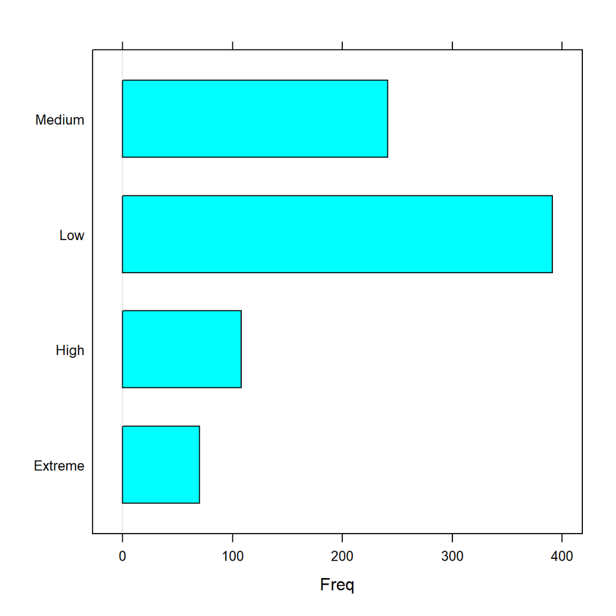

```r
#create factors
hbf$vert_group <- as.factor(hbf$vert_group)
hbf$major_stress_pop <- as.factor(hbf$major_stress_pop)
hbf$fem_bc <- as.factor(hbf$fem_bc)
hbf$genus <- as.factor(hbf$genus)
hbf$species <- as.factor(hbf$species)
hbf$common_name <- as.factor(hbf$common_name)
hbf$breeding_cycle <- as.factor(hbf$breeding_cycle)
hbf$life_stage <- as.factor(hbf$life_stage)
hbf$capture_method <- as.factor(hbf$capture_method)
hbf$sample_method <- as.factor(hbf$sample_method)

#view fem_bc counts
barchart(hbf$fem_bc)
```

### Data Splitting

The variable of interest in this supervised learning method is the mean baseline cortisone concentration in females. After cleaning the data, we have 810 observations remaining. We will split the data 70/30 stratified by the response for an even distribution of model training, so 70% of the data will be utilized in training the model and the remaining 30% of the data will be utilized for testing the data

```r
#set the seed for reproducibility
set.seed(37)

#split the data
split <- initial_split(hbf, strata = fem_bc, prop = 0.7)
split
```

```
## <Training/Testing/Total>
## <566/244/810>
```

```r
#create training and testing sets from the split
hbf_train <- training(split)
hbf_test <- testing(split)
```

### Check Correlations

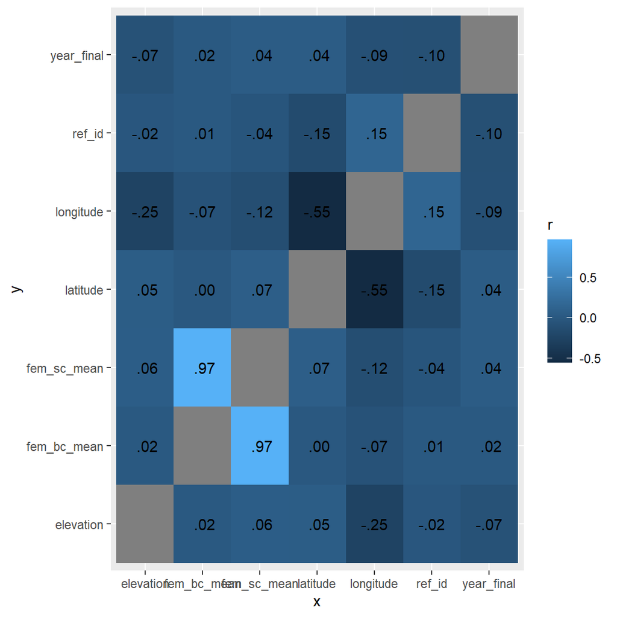

```r
cor_hbf <- as.tibble(hbf_train) %>%
  correlate()
cor_hbf %>%
  stretch() %>%
  ggplot(aes(x,y,fill=r)) +
  geom_tile() +
  geom_text(aes(label=as.character(fashion(r))))
```

```r
hbf <- hbf %>%
  dplyr::select(-('fem_bc_mean'))
hbf <- hbf %>%
  dplyr::select(-('fem_sc_mean'))
summary(hbf)
```

```
##      vert_group            genus           species
##  Amphibian: 45   Somateria    : 46   mollissima: 44
##  Bird     :468   Passer       : 34   domesticus: 34
##  Fish     : 72   Zonotrichia  : 34   butcheri  : 30
##  Mammal   : 60   Acanthopagrus: 30   leucophrys: 18
##  Reptile  :165   Crotalus     : 24   adeliae   : 17
##                  Sceloporus   : 19   aalge     : 14
##                  (Other)      :623   (Other)   :653
##                 common_name     latitude         longitude
##  Common eider         : 44   Min.   :-77.219   Min.   :-164.93
##  House sparrow        : 34   1st Qu.:  9.554   1st Qu.:-108.87
##  Southern black bream : 30   Median : 35.000   Median : -75.19
##  White-crowned sparrow: 18   Mean   : 24.513   Mean   : -33.01
##  Adelie penguin       : 17   3rd Qu.: 48.429   3rd Qu.:  20.12
##  Common guillemot     : 14   Max.   : 78.917   Max.   : 175.85
##  (Other)              :653
##    elevation         year_final                 breeding_cycle
##  Min.   :-1000.0   Min.   :1979                        : 30
##  1st Qu.:   15.0   1st Qu.:1993   Breeding             :602
##  Median :   87.0   Median :1999   Breeding             :  1
##  Mean   :  357.2   Mean   :1999   Breeding, Nonbreeding: 15
##  3rd Qu.:  400.0   3rd Qu.:2007   Nonbreeding          :162
##  Max.   : 4790.0   Max.   :2015
##                    NA's   :38
##                   life_stage  capture_method      sample_method
##                        :392   Trap   :352    Active      :486
##  Incubation            :102   Hand   :147    Passive     :106
##  Young care            : 94   Nesting:120                : 81
##  Prebreeding           : 65          :105    Attractant  : 36
##  Laying                : 46   Noose  : 42    Anesthetized: 30
##  Incubation, Young care: 16   Fishing: 33    Killed      : 30
##  (Other)               : 95   (Other): 11    (Other)     : 41
##                                                                       major_stress_pop
##                                                                               :796
##  habitat fragmentation                                                        :  3
##  Heat                                                                         :  1
##  Low Food                                                                     :  3
##  Tourism                                                                      :  5
##  Urban                                                                        :  1
##  Watercraft collision, line entanglement, harmful algal bloom, and cold stress:  1
##      ref_id          fem_bc
##  Min.   :  1.0   Extreme: 70
##  1st Qu.:168.0   High   :108
##  Median :325.0   Low    :391
##  Mean   :327.9   Medium :241
##  3rd Qu.:467.0
##  Max.   :648.0
##
```

## Model Building

Utilizing one recipe with determined variables, four models are created with the HormoneBase data to predict the categorical response of the mean of fem_bc. These models use different modeling techniques. The difference for these models is determined in performance reviews in later sections. Classification, boosted, random forest, and K-Nearest Neighbor models are reviewed. In each model, we set up the workflow, add the new model, and add the established recipe. We then set up the tuning grid with the parameters that we want tuned, and how many different levels of tuning Tune the model with certain parameters of choice Select the most accurate model from all of the tuning, finalize the workflow with those tuning parameters Fit that model with our workflow to the training data set.

### Recipe Building

Fold the training set using *v*-fold cross-validation, with `v = 5`. Stratify on the outcome variable.

```r
hbf_fold <- vfold_cv(hbf_train, v = 5, strata = fem_bc)
```

Now we can set up a recipe to predict the categorized mean fem_bc with selected predictors, using dummy-codes for factors, and with all predictors centered and scaled. Also note capture_method, and sample_method are uninteresting since these do not affect base method. Genus and Species and common name are also extra granular when vert_group is analyzed. Breeding cycle and life stage is variable since these observations were made over various cycles and stages so are removed. Year is also deemed unnecessary since the major stress pop is more relevant. Thus, the recipe utilizes predictor variables: vert_group, latitude, longitude, elevation, and major_stress_pop.

```r
hbf_recipe <- recipe(fem_bc ~ vert_group+ latitude+ longitude+ elevation+  major_stress_pop, data=hbf_train) %>%
  step_dummy(c(vert_group, major_stress_pop)) %>%
  step_normalize(all_predictors())
```

## Model Option Evaluation

### Classification Model

Next, we will set up a classification tree model and workflow for a classification tree plot.

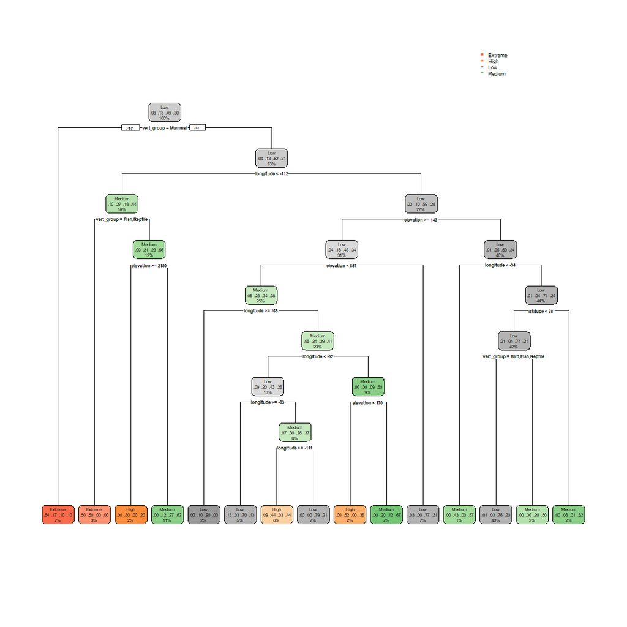

```r
tree_spec <- decision_tree() %>%
  set_engine("rpart")

class_tree_spec <- tree_spec %>%
  set_mode("classification")

class_tree_fit <- class_tree_spec %>%
  fit(fem_bc ~ vert_group+ latitude+ longitude+ elevation+ major_stress_pop, data=hbf_train)


class_tree_fit %>%
  extract_fit_engine() %>%
  rpart.plot()
```

```r
class_tree_wf <- workflow() %>%
  add_model(class_tree_spec %>%
              set_args(cost_complexity = tune())) %>%
  add_recipe(hbf_recipe)


param_grid <- grid_regular(cost_complexity(range = c(-3, -1)), levels = 4)

tune_res <- tune_grid(
  class_tree_wf,
  resamples = hbf_fold,
  grid = param_grid,
  metrics = metric_set(roc_auc)
)
```

```r
collect_metrics(tune_res)
```

```
## # A tibble: 4 × 7
##   cost_complexity .metric .estimator  mean     n std_err .config
##             <dbl> <chr>   <chr>      <dbl> <int>   <dbl> <chr>
## 1         0.001   roc_auc hand_till  0.789     5 0.0109  Preprocessor1_Model1
## 2         0.00464 roc_auc hand_till  0.783     5 0.0112  Preprocessor1_Model2
## 3         0.0215  roc_auc hand_till  0.740     5 0.0143  Preprocessor1_Model3
## 4         0.1     roc_auc hand_till  0.509     5 0.00875 Preprocessor1_Model4
```

```r
best_model <- select_best(tune_res, metric='roc_auc')
hbf_tree_best <- finalize_workflow(class_tree_wf, best_model)
hbf_tree_best_fit <- fit(hbf_tree_best, data=hbf_train)
pruned_tree <- augment(hbf_tree_best_fit, hbf_train, type='prob') %>%
  roc_auc(truth=fem_bc, estimate=.pred_Medium:.pred_Extreme)

pruned_tree
```

```
## # A tibble: 1 × 3
##   .metric .estimator .estimate
##   <chr>   <chr>          <dbl>
## 1 roc_auc hand_till      0.193
```

```r
pruned_metrics <- collect_metrics(tune_res)
mean(pruned_metrics$mean)
```

```
## [1] 0.7050104
```

### Random Forest Model

Now set up a random forest model and workflow by using the ‘ranger’ engine, setting ‘importance = impurity’, and tuning ‘mtry’, ‘trees’, and ‘min_n’. Using the documentation for ‘rand_forest()’, There are 5 variables to select from. As MTRY is the number of variables to randomly sample as, it shouldn’t be less than 1 variable and it shouldn’t be more than the max variables.

```r
hbf_forest_model <- rand_forest(mtry=tune(), trees=tune(), min_n=tune()) %>%
  set_engine("ranger", importance="impurity") %>%
  set_mode("classification")

hbf_forest_wkflow <- workflow() %>%
  add_model(hbf_forest_model) %>%
  add_recipe(hbf_recipe)

param1_grid <- grid_regular(mtry(range= c(1,8)),
                          trees(range = c(10,20)),
                           min_n(range = c(1,10)),
                          levels = 5
)
```

And now we must review this model through a ROC AUC metric Almost consistently, the mean ROC improves as more variables are added regardless of number of trees. Here, minimal node size of 5 appears to have best performance.

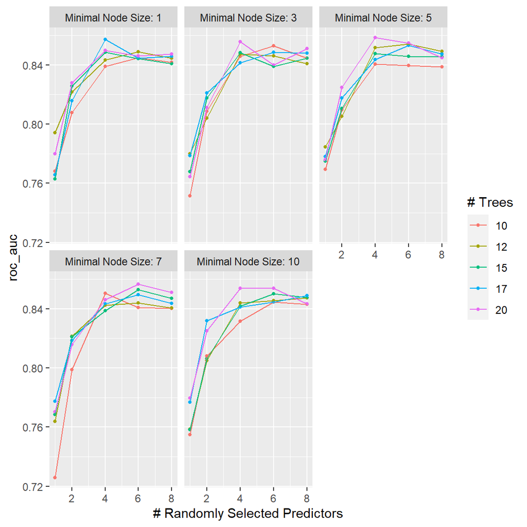

```r
tune_forest <- tune_grid(
  hbf_forest_wkflow,
  resamples = hbf_fold,
  grid = param1_grid,
  metrics = metric_set(roc_auc)
)
autoplot(tune_forest)
```

The ROC AUC of the best-performing random forest model on the folds is

```r
collect_metrics(tune_forest)
```

```
## # A tibble: 125 × 9
##     mtry trees min_n .metric .estimator  mean     n std_err .config
##    <int> <int> <int> <chr>   <chr>      <dbl> <int>   <dbl> <chr>
##  1     1    10     1 roc_auc hand_till  0.768     5 0.0200  Preprocessor1_Model…
##  2     2    10     1 roc_auc hand_till  0.808     5 0.0157  Preprocessor1_Model…
##  3     4    10     1 roc_auc hand_till  0.839     5 0.0146  Preprocessor1_Model…
##  4     6    10     1 roc_auc hand_till  0.845     5 0.00814 Preprocessor1_Model…
##  5     8    10     1 roc_auc hand_till  0.842     5 0.0148  Preprocessor1_Model…
##  6     1    12     1 roc_auc hand_till  0.794     5 0.0110  Preprocessor1_Model…
##  7     2    12     1 roc_auc hand_till  0.822     5 0.0173  Preprocessor1_Model…
##  8     4    12     1 roc_auc hand_till  0.843     5 0.0138  Preprocessor1_Model…
##  9     6    12     1 roc_auc hand_till  0.849     5 0.0180  Preprocessor1_Model…
## 10     8    12     1 roc_auc hand_till  0.844     5 0.0174  Preprocessor1_Model…
## # … with 115 more rows
```

```r
best_complexity <- select_best(tune_forest, metric="roc_auc")

hbf_forest_best <- finalize_workflow(hbf_forest_wkflow, best_complexity)

hbf_forest_best_fit <- fit(hbf_forest_best, data=hbf_train)

random_forest <- augment(hbf_forest_best_fit, hbf_train, type="prob") %>%
  roc_auc(truth=fem_bc, estimate = .pred_Medium:.pred_Extreme)

random_forest
```

```
## # A tibble: 1 × 3
##   .metric .estimator .estimate
##   <chr>   <chr>          <dbl>
## 1 roc_auc hand_till      0.230
```

```r
forest_metrics <- collect_metrics(tune_forest)
mean(forest_metrics$mean)
```

```
## [1] 0.8245353
```

#### Variable Importance Plot

Let’s look at the variable importance plot, using `vip()` with the best-performing random forest model fit on the training set.

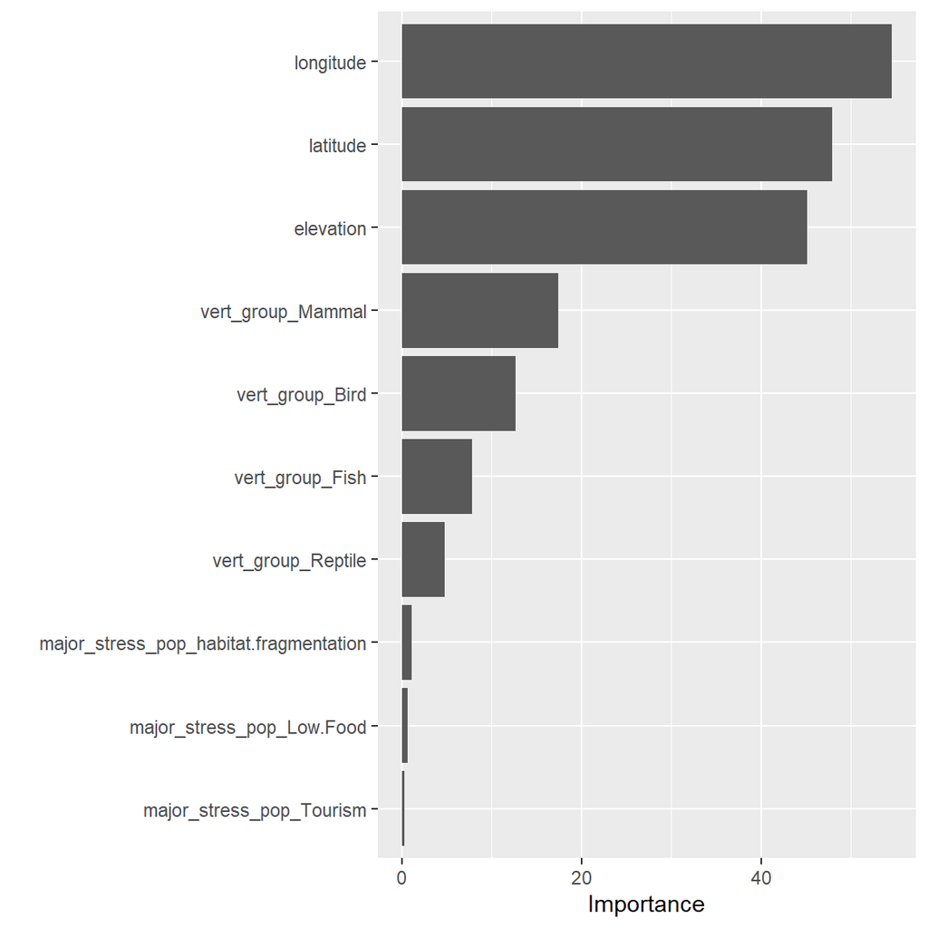

```r
extract_fit_engine(hbf_forest_best_fit) %>%
  vip()
```

### Boosted Tree Model

Now, we will set up the third model, a boosted tree model and workflow, using the ‘xgboost’ engine, and tuning ‘trees’ and a regular grid

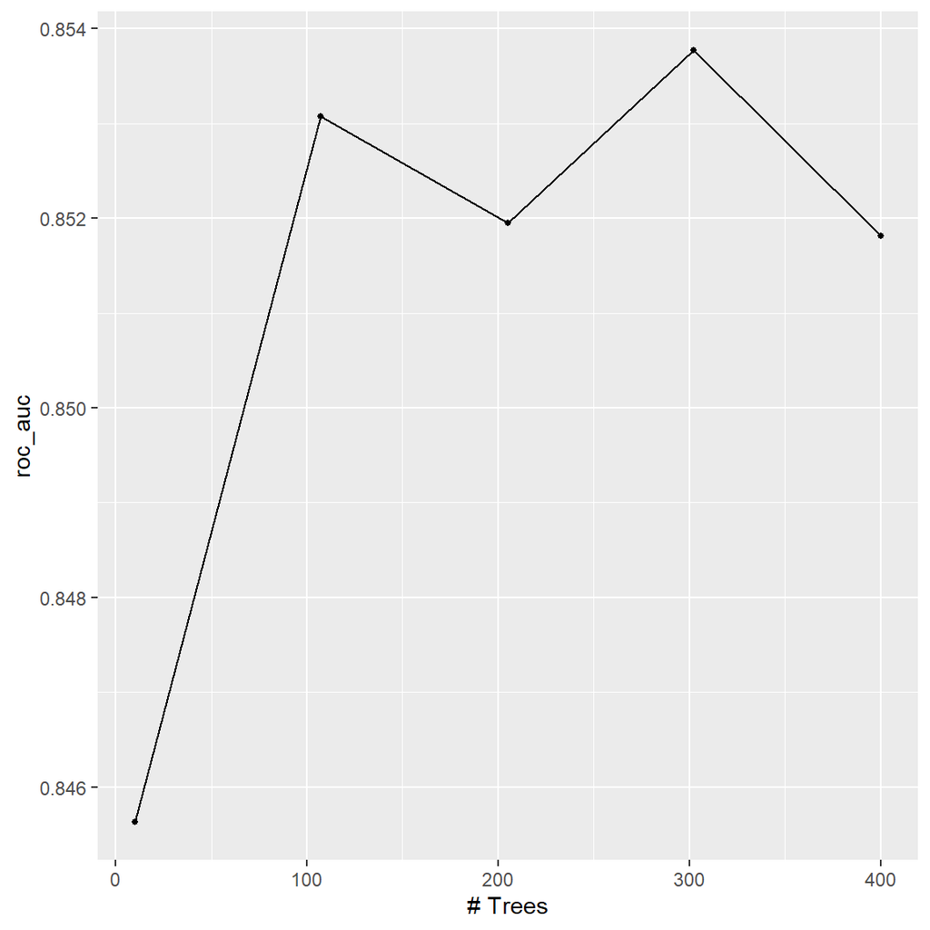

```r
hbf_boost_model <- boost_tree(trees = tune()) %>%
  set_engine("xgboost") %>%
  set_mode("classification")
hbf_boost_wkflow <- workflow() %>%
  add_model(hbf_boost_model) %>%
  add_recipe(hbf_recipe)
param2_grid <- grid_regular(trees(range(c(10,400))),levels=5)
hbf_tune_boost <- tune_grid(hbf_boost_wkflow,
                        resamples=hbf_fold,
                        grid = param2_grid,
                        metrics=metric_set(roc_auc))

best_complexity <- select_best(hbf_tune_boost, metric="roc_auc")

hbf_boost_best <- finalize_workflow(hbf_boost_wkflow, best_complexity)

hbf_boost_best_fit <- fit(hbf_boost_best, data=hbf_train)

boost <- augment(hbf_boost_best_fit, hbf_train, type="prob") %>%
  roc_auc(truth=fem_bc, estimate = .pred_Medium:.pred_Extreme)
autoplot(hbf_tune_boost)
```

```r
boost
```

```
## # A tibble: 1 × 3
##   .metric .estimator .estimate
##   <chr>   <chr>          <dbl>
## 1 roc_auc hand_till      0.238
```

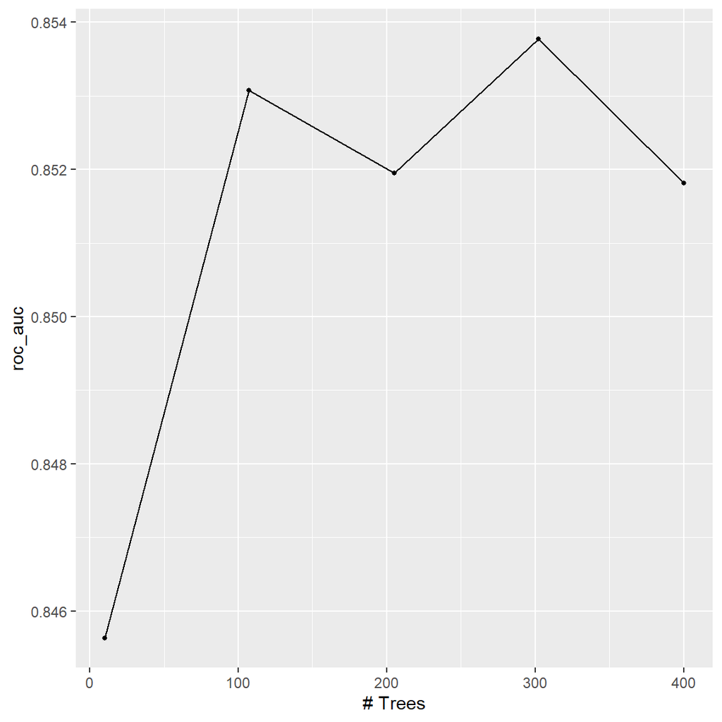

```r
autoplot(hbf_tune_boost)
```

```r
boost_metrics <- collect_metrics(hbf_tune_boost)
mean(boost_metrics$mean)
```

```
## [1] 0.8512492
```

### K-Nearest Neighbor Plot

Here we look at a weighted K nearest neighbor model.

```r
hbf_knn_model <- nearest_neighbor(neighbors = tune(),
  mode = "classification") %>%
  set_engine("kknn")

hbf_knn_workflow <- workflow() %>%
  add_model(hbf_knn_model) %>%
  add_recipe(hbf_recipe)
# set-up tuning grid
hbf_knn_params <- parameters(hbf_knn_model)
# define grid
hbf_knn_grid <- grid_regular(hbf_knn_params, levels = 2)

hbf_knn_tune <- tune_grid(hbf_knn_workflow,
                          resamples = hbf_fold,
                          grid = hbf_knn_grid,
                          metrics=metric_set(roc_auc))

best_complexity <- select_best(hbf_knn_tune, metric="roc_auc")

hbf_knn_best <- finalize_workflow(hbf_knn_workflow, best_complexity)

hbf_knn_best_fit <- fit(hbf_knn_best, data=hbf_train)

knn <- augment(hbf_knn_best_fit, hbf_train, type="prob") %>%
  roc_auc(truth=fem_bc, estimate = .pred_Medium:.pred_Extreme)

knn
```

```
## # A tibble: 1 × 3
##   .metric .estimator .estimate
##   <chr>   <chr>          <dbl>
## 1 roc_auc hand_till      0.249
```

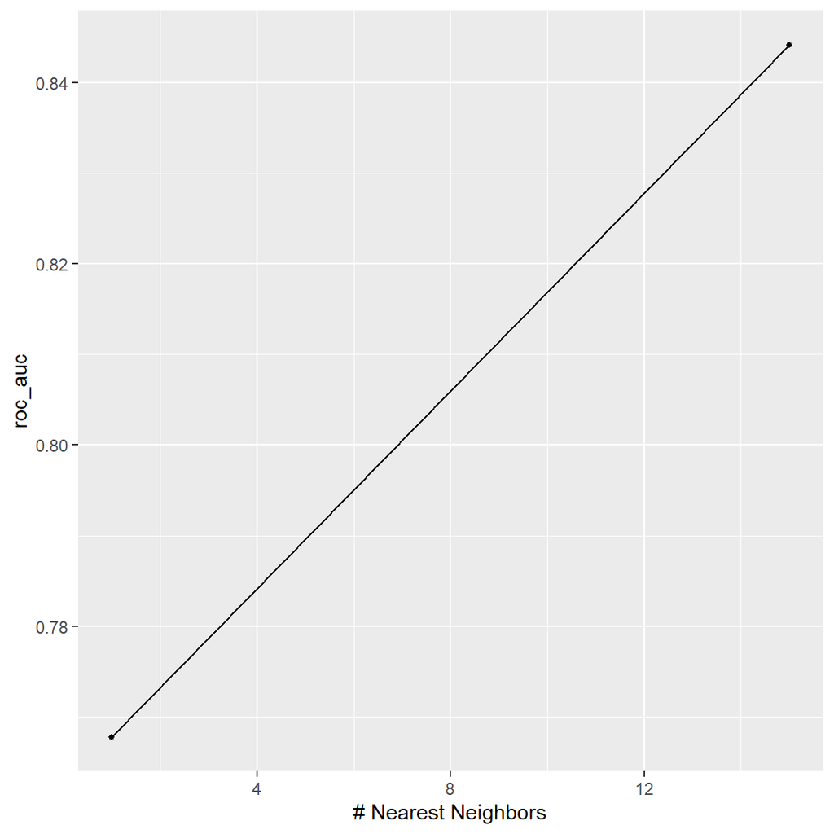

```r
autoplot(hbf_knn_tune)
```

```r
knn_metrics <- collect_metrics(hbf_knn_tune)
mean(knn_metrics$mean)
```

```
## [1] 0.8059674
```

## Best Fit Model

The metric of performance evaluated is roc_auc because that is what shows the most significant level of efficiency in a classification model where the data is not perfectly balanced. This essentially calculates the area under the curve for the receiver operating characteristic (ROC) curve, which highlights the trade-off between sensibility and sensitivity.

```r
knn
```

```
## # A tibble: 1 × 3
##   .metric .estimator .estimate
##   <chr>   <chr>          <dbl>
## 1 roc_auc hand_till      0.249
```

```r
boost
```

```
## # A tibble: 1 × 3
##   .metric .estimator .estimate
##   <chr>   <chr>          <dbl>
## 1 roc_auc hand_till      0.238
```

```r
pruned_tree
```

```
## # A tibble: 1 × 3
##   .metric .estimator .estimate
##   <chr>   <chr>          <dbl>
## 1 roc_auc hand_till      0.193
```

```r
random_forest
```

```
## # A tibble: 1 × 3
##   .metric .estimator .estimate
##   <chr>   <chr>          <dbl>
## 1 roc_auc hand_till      0.230
```

```r
boost_metrics <- collect_metrics(hbf_tune_boost)
forest_metrics <- collect_metrics(tune_forest)
pruned_metrics <- collect_metrics(tune_res)
knn_metrics <- collect_metrics(hbf_knn_tune)



metrics_mean <- data.frame(AUC = c(mean(boost_metrics$mean), mean(forest_metrics$mean), mean(pruned_metrics$mean), mean(knn_metrics$mean)),
                           Name = c("Boost","Random Forest", "Pruned Tree", "KNN"))
metrics_mean
```

```
##         AUC          Name
## 1 0.8512492         Boost
## 2 0.8245353 Random Forest
## 3 0.7050104   Pruned Tree
## 4 0.8059674           KNN
```

```r
best_complexity <- select_best(hbf_tune_boost, metric="roc_auc")

hbf_boost_best <- finalize_workflow(hbf_boost_wkflow, best_complexity)

hbf_boost_best_fit <- fit(hbf_boost_best, data=hbf_train)

boost_mod <- augment(hbf_boost_best_fit, hbf_train, type="prob") %>%
  roc_auc(truth=fem_bc, estimate = .pred_Medium:.pred_Extreme)

boost_mod
```

```
## # A tibble: 1 × 3
##   .metric .estimator .estimate
##   <chr>   <chr>          <dbl>
## 1 roc_auc hand_till      0.238
```

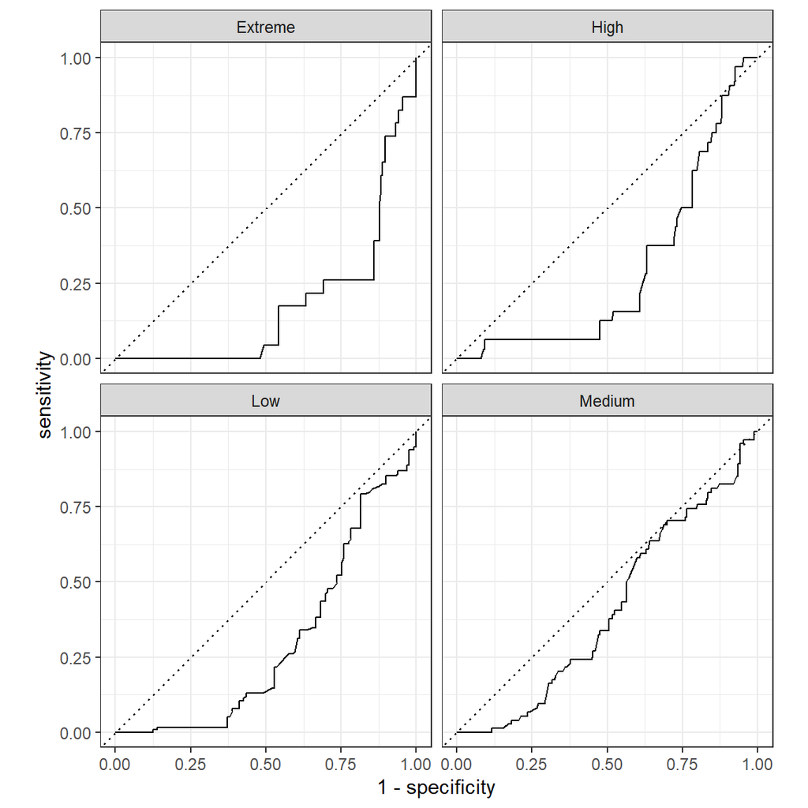

```r
augment(hbf_boost_best_fit, hbf_test) %>%
  roc_curve(truth=fem_bc, estimate = .pred_Medium:.pred_Extreme) %>%
  autoplot()
```

Medium predictions on the test data appear to perform almost decently but the remainder of the values are quite poorly predicted.

## Conclusion

Although we see the location is highly predictive for the categorical female corticosterone/cortisol stress levels in animals around the world, the data gathered relevant to the stress levels is minimal and only appears to address less than 25% of the response. What this means is, even though the boosted model tuned performed the best, it still doesn’t do a great job at actually predicting the response variable so additional data collections, variables, and studies must be performed to identify the reasons for variable stress hormone concentrations.